# Sion - Bikesharing dataset

Yooby Gigandet, Clarence Koehle, Jérémy Olivier, and Arturo García Luna Beltrán

14 mayo, 2022

#### **Sion bike sharing**

Our work is to forecast the number of bikes available for every 10 minutes of Wednesday, May 25th, at every stations in the city of Sion.

To do so, we first compile for each stations the number of bikes available only on Wednesdays. It will help us to gain some insights on particular trends for this day of the week.

Most of the stations show a pattern between the hours from 06:00 to 12:00, where the amount of bikes decrease and then increase from 12:00 to 18:00. There are special cases in which those patterns are at the inverse, those signs could be related by the location of this stations, and the purpose of their users.

- **Stations that Increase - Decrease**
  - Campus Energypolis
  - Hôpital - CRR
  - Gare de Sion Sud
  - Gare de Sion Nord (E-Bike)
- **Stations that Decrease - Increase**
  - Bietschhorn
  - Platta (E-Bike)
  - P+R Potence
  - Ancien Stand (E-Bike)

#### **Bietschhorn Station**

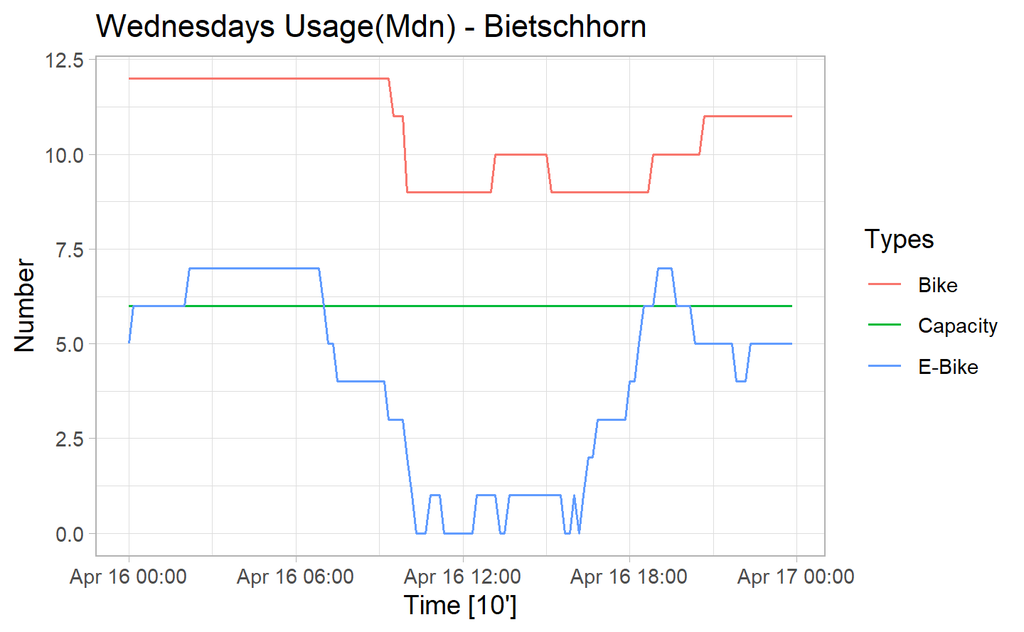

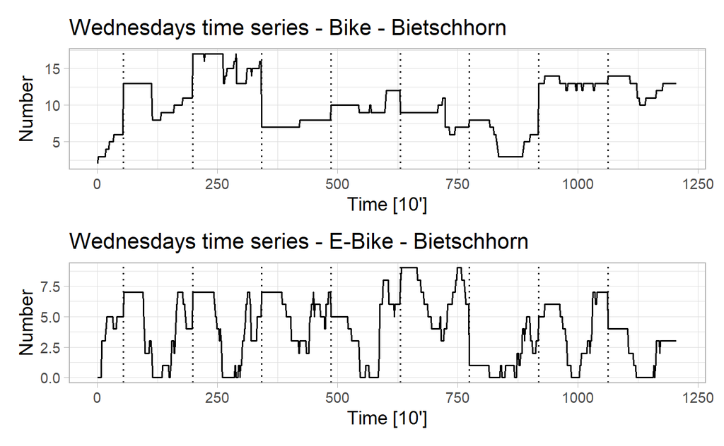

```
#> # A tibble: 1 x 3
#>   Types kpss_stat kpss_pvalue
#>   <chr>     <dbl>       <dbl>
#> 1 Bike      0.909        0.01
#> # A tibble: 1 x 3
#>   Types  kpss_stat kpss_pvalue
#>   <chr>      <dbl>       <dbl>
#> 1 E-Bike     0.814        0.01
```

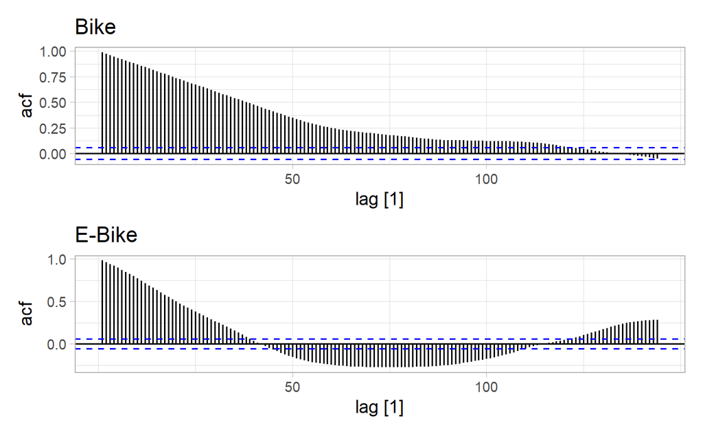

#### **Forecast**

> **Bike**

```
#> # A tibble: 4 x 11
#>   .model     Types .type     ME  RMSE   MAE     MPE  MAPE  MASE RMSSE
#>   <chr>      <chr> <chr>  <dbl> <dbl> <dbl>   <dbl> <dbl> <dbl> <dbl>
#> 1 Combinati~ Bike  Test   0.220  1.35  1.22   0.545  9.96  12.9  2.40
#> 2 ETS        Bike  Test  -1.43   1.96  1.43 -12.7   12.7   15.1  3.48
#> 3 ARIMA      Bike  Test  -1.45   1.97  1.45 -12.9   12.9   15.4  3.51
#> 4 TSLM       Bike  Test   3.54   3.77  3.54  27.2   27.2   37.5  6.70
#> # ... with 1 more variable: ACF1 <dbl>
#> Series: Bike
#> Model: TSLM
#>
#> Residuals:
#>    Min     1Q Median     3Q    Max
#>  -6.50  -2.56  -0.21   2.56   8.39
#>
#> Coefficients:
#>                     Estimate Std. Error t value Pr(>|t|)
#> (Intercept)          13.6702     0.2836   48.21  < 2e-16 ***
#> Air_Temperature       0.6514     3.3953    0.19     0.85
#> Precipitation       -32.8301    22.2249   -1.48     0.14
#> Virtual_Temperature  -1.0236     3.3800   -0.30     0.76
#> Wind_Speed            0.0939     0.0145    6.49  1.4e-10 ***
#> ---
#> Signif. codes:  0 '***' 0.001 '**' 0.01 '*' 0.05 '.' 0.1 ' ' 1
#>
#> Residual standard error: 3.14 on 1003 degrees of freedom
#> Multiple R-squared: 0.197,   Adjusted R-squared: 0.194
#> F-statistic: 61.6 on 4 and 1003 DF, p-value: <2e-16
```

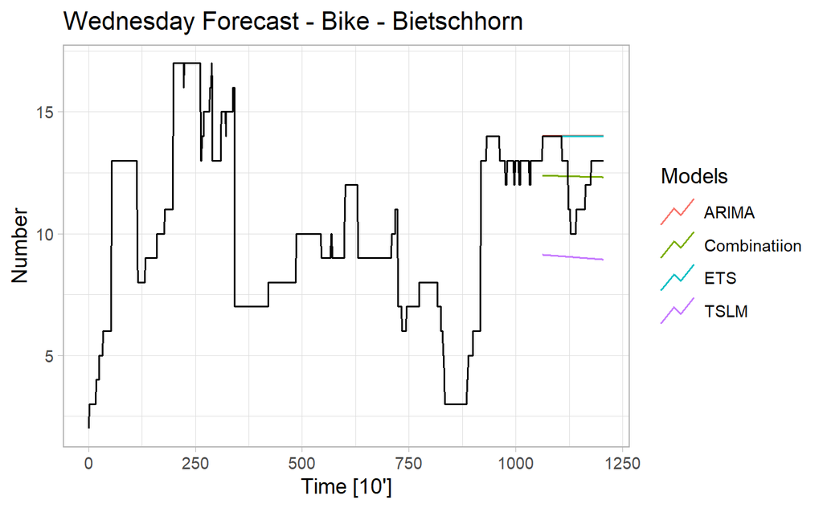

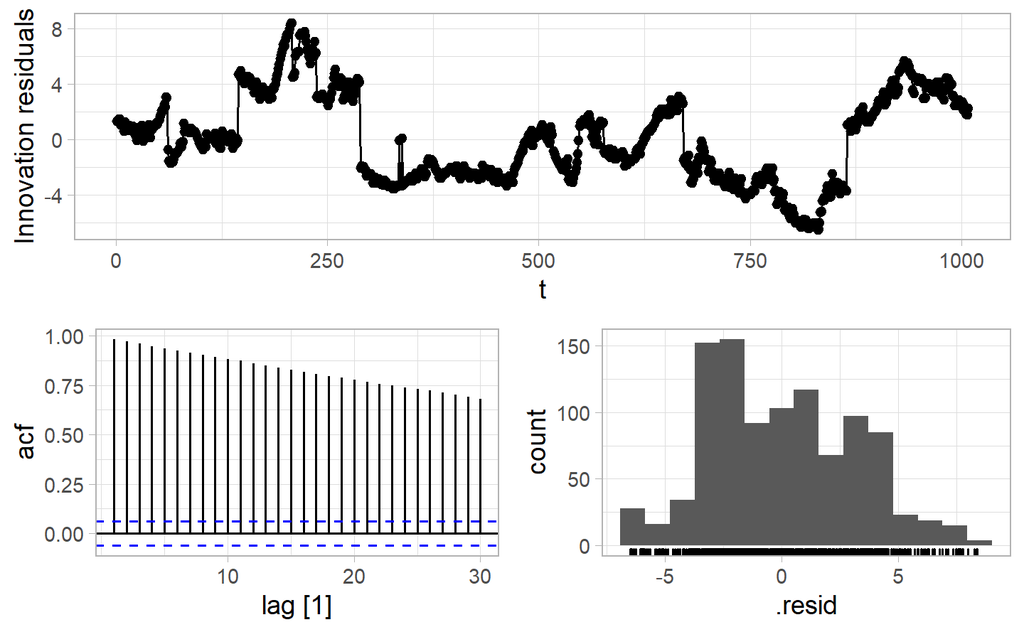

> **E-Bike**

```
#> # A tibble: 4 x 11
#>   .model Types .type     ME  RMSE   MAE   MPE  MAPE  MASE RMSSE  ACF1
#>   <chr>  <chr> <chr>  <dbl> <dbl> <dbl> <dbl> <dbl> <dbl> <dbl> <dbl>
#> 1 ETS    E-Bi~ Test  -0.681  1.68  1.26  -Inf   Inf  7.89  3.37 0.979
#> 2 Combi~ E-Bi~ Test  -1.06   2.06  1.65  -Inf   Inf 10.3   4.12 0.983
#> 3 TSLM   E-Bi~ Test  -1.51   2.18  1.61  -Inf   Inf 10.1   4.37 0.977
#> 4 ARIMA  E-Bi~ Test  -1.44   2.48  2.09  -Inf   Inf 13.0   4.98 0.986
#> Series: E-Bike
#> Model: TSLM
#>
#> Residuals:
#>    Min     1Q Median     3Q    Max
#>  -5.04  -1.97  -0.02   1.77   5.60
#>
#> Coefficients:
#>                     Estimate Std. Error t value Pr(>|t|)
#> (Intercept)           7.1027     0.2183   32.53   <2e-16 ***
#> Air_Temperature      -3.5247     2.6140   -1.35    0.178
#> Precipitation        14.0951    17.1112    0.82    0.410
#> Virtual_Temperature   3.2900     2.6023    1.26    0.206
#> Wind_Speed           -0.0274     0.0111   -2.46    0.014 *
#> ---
#> Signif. codes:  0 '***' 0.001 '**' 0.01 '*' 0.05 '.' 0.1 ' ' 1
#>
#> Residual standard error: 2.42 on 1003 degrees of freedom
#> Multiple R-squared: 0.223,   Adjusted R-squared: 0.22
#> F-statistic: 71.8 on 4 and 1003 DF, p-value: <2e-16
```

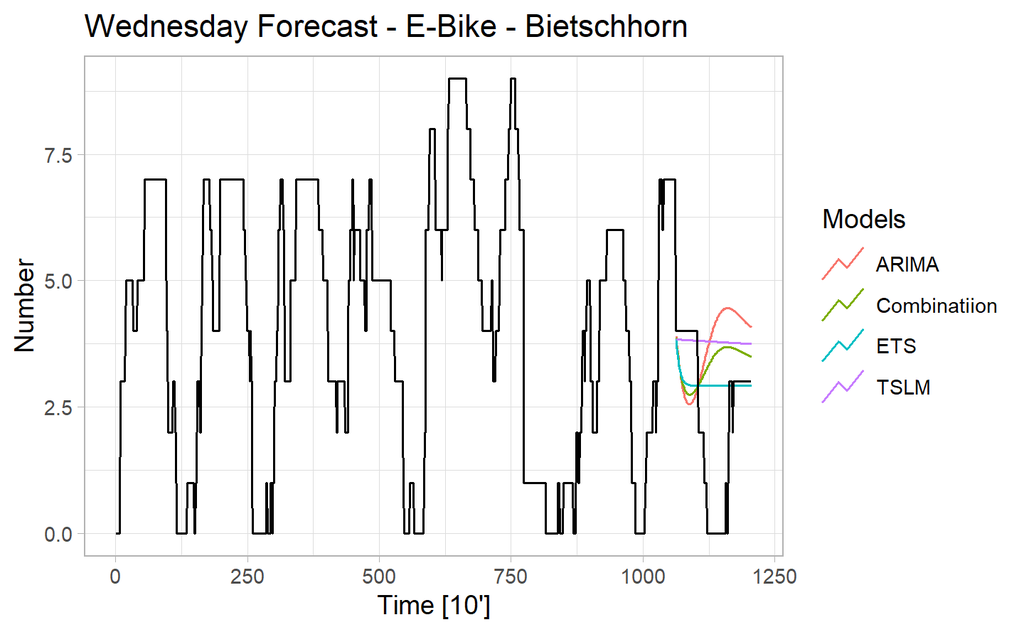

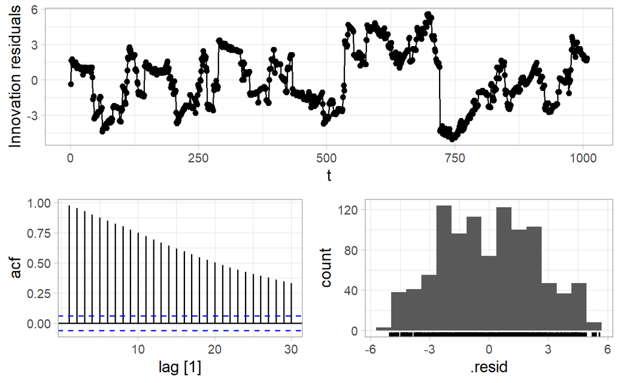

#### **Agasse Station**

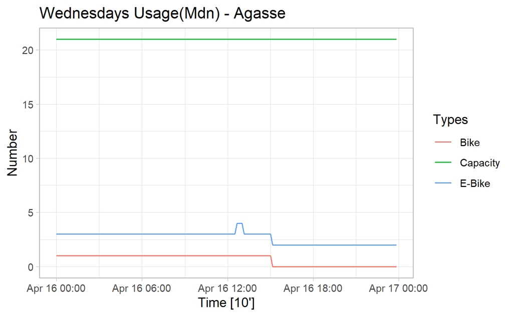

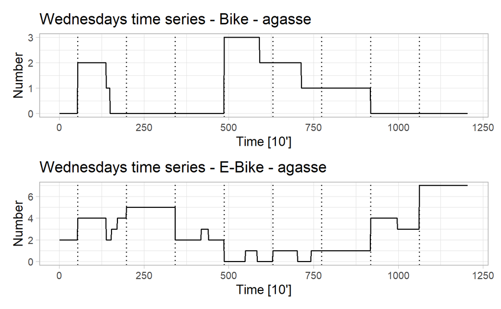

```
#> # A tibble: 1 x 3
#>   Types kpss_stat kpss_pvalue
#>   <chr>     <dbl>       <dbl>
#> 1 Bike       1.69        0.01
#> # A tibble: 1 x 3
#>   Types  kpss_stat kpss_pvalue
#>   <chr>      <dbl>       <dbl>
#> 1 E-Bike      2.86        0.01
```

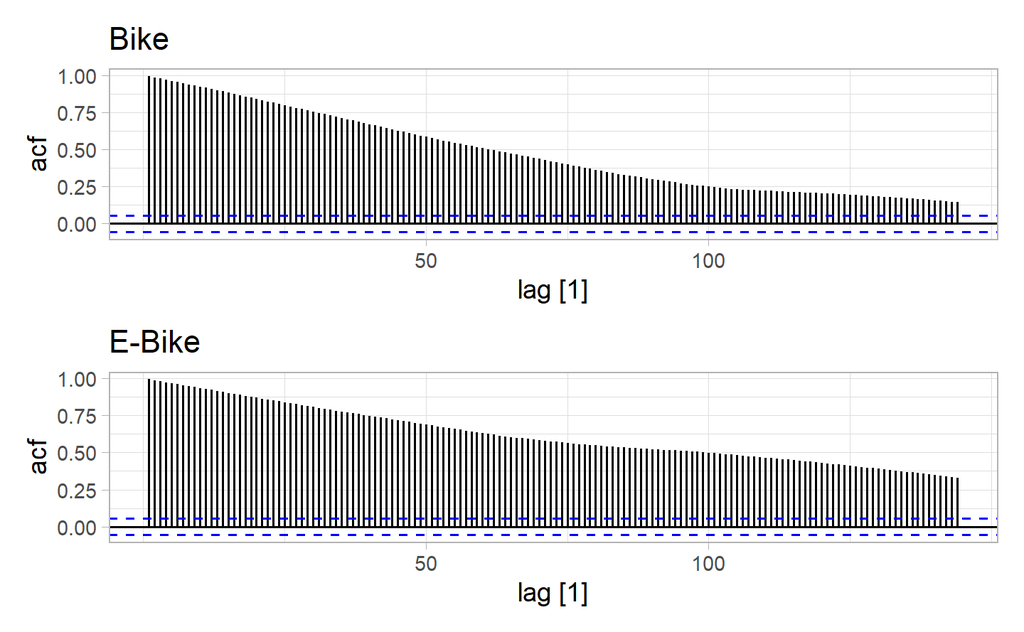

#### **Blancherie Station**

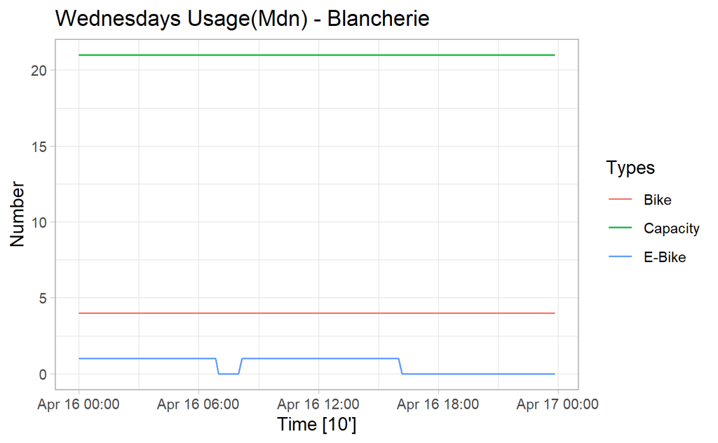

As we can see on the graphs below, it does not seem to have any patterns.

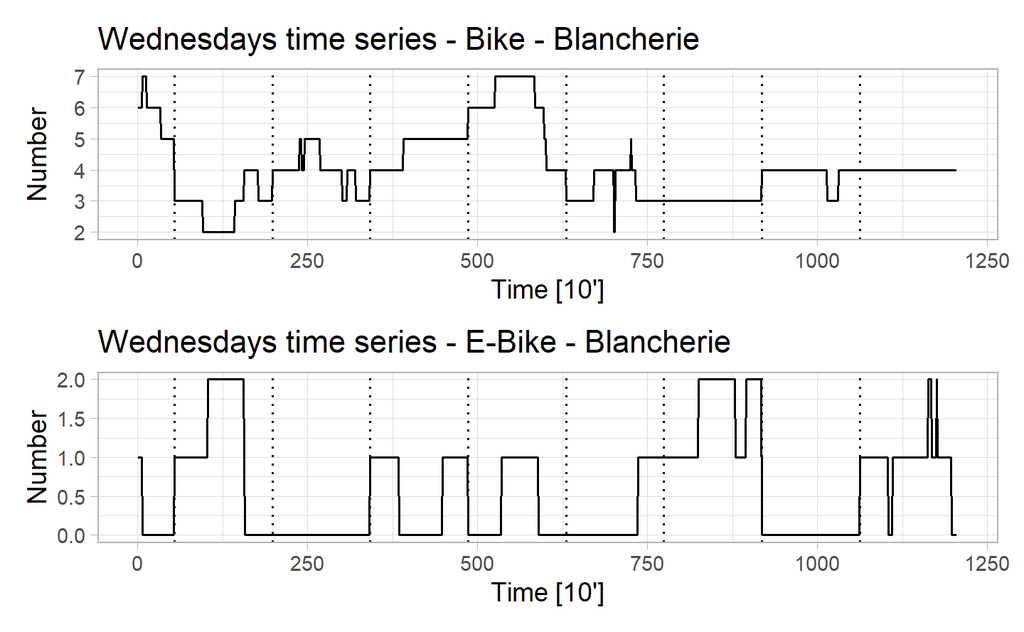

```
#> # A tibble: 1 x 3
#>   Types kpss_stat kpss_pvalue
#>   <chr>     <dbl>       <dbl>
#> 1 Bike       1.13        0.01
#> # A tibble: 1 x 3
#>   Types  kpss_stat kpss_pvalue
#>   <chr>      <dbl>       <dbl>
#> 1 E-Bike     0.625      0.0203
```

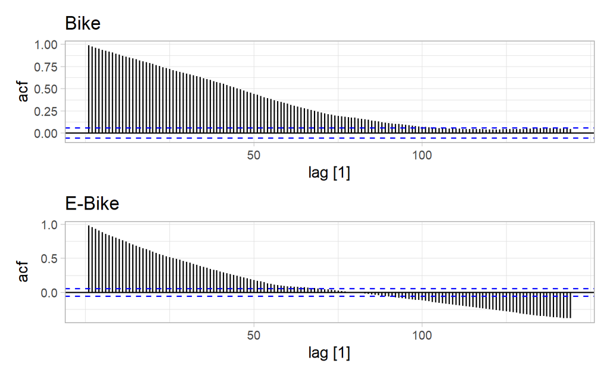

#### **UNIL/UNIGE Bramois Station**

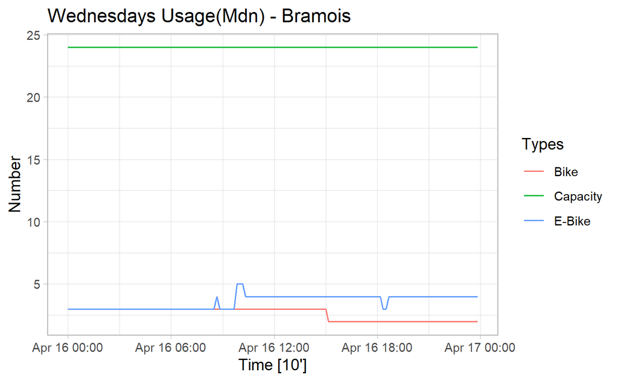

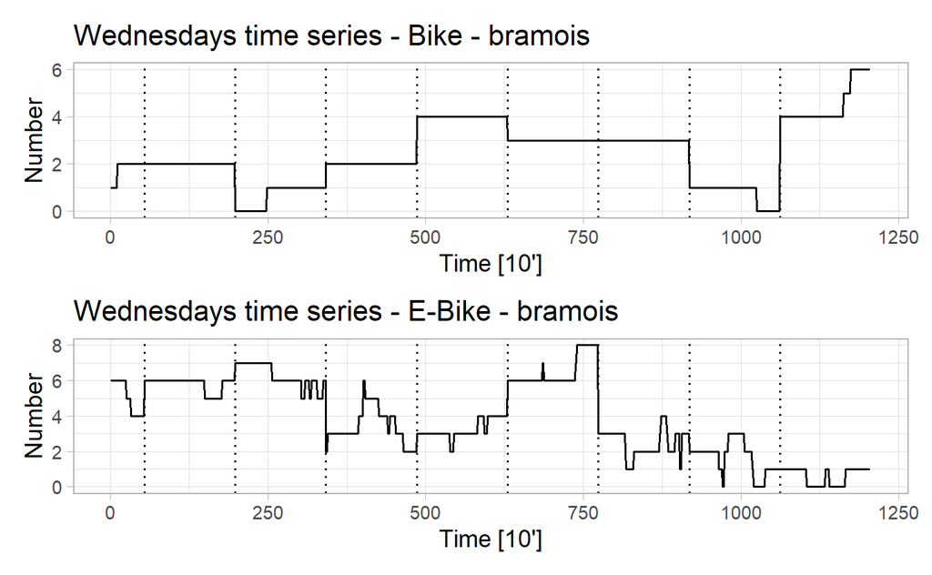

```
#> # A tibble: 1 x 3
#>   Types kpss_stat kpss_pvalue
#>   <chr>     <dbl>       <dbl>
#> 1 Bike       3.07        0.01
#> # A tibble: 1 x 3
#>   Types  kpss_stat kpss_pvalue
#>   <chr>      <dbl>       <dbl>
#> 1 E-Bike      8.08        0.01
```

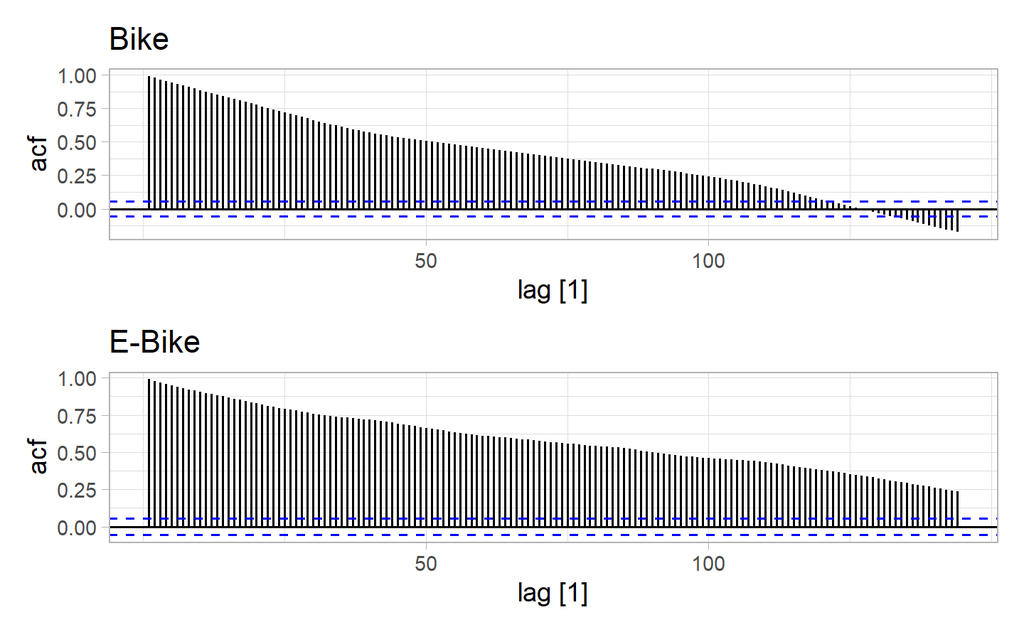

#### **Campus Energypolis Station**

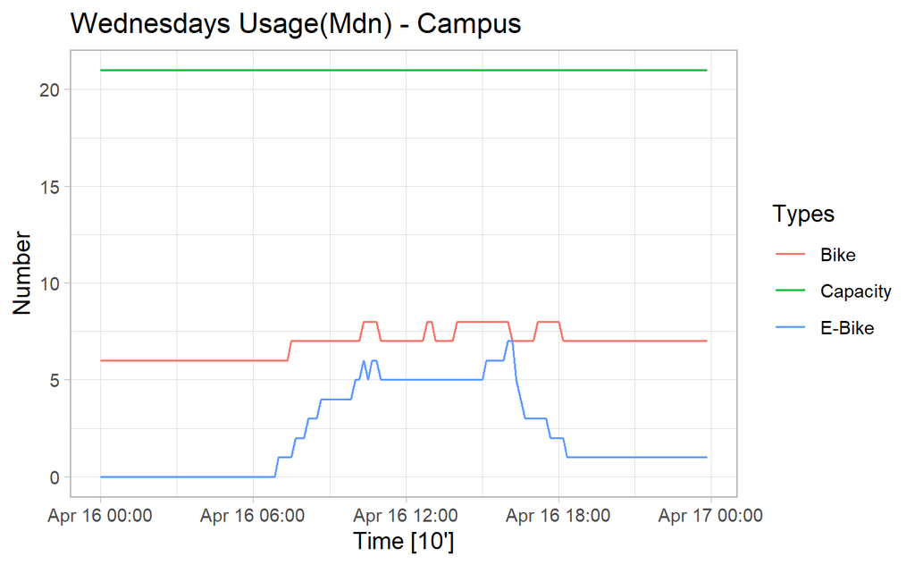

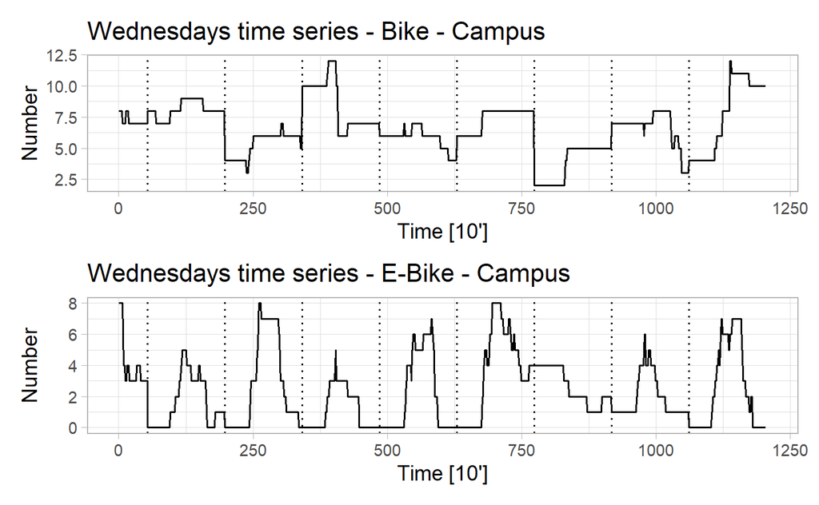

```
#> # A tibble: 1 x 3
#>   Types kpss_stat kpss_pvalue
#>   <chr>     <dbl>       <dbl>
#> 1 Bike      0.763        0.01
#> # A tibble: 1 x 3
#>   Types  kpss_stat kpss_pvalue
#>   <chr>      <dbl>       <dbl>
#> 1 E-Bike     0.218         0.1
```

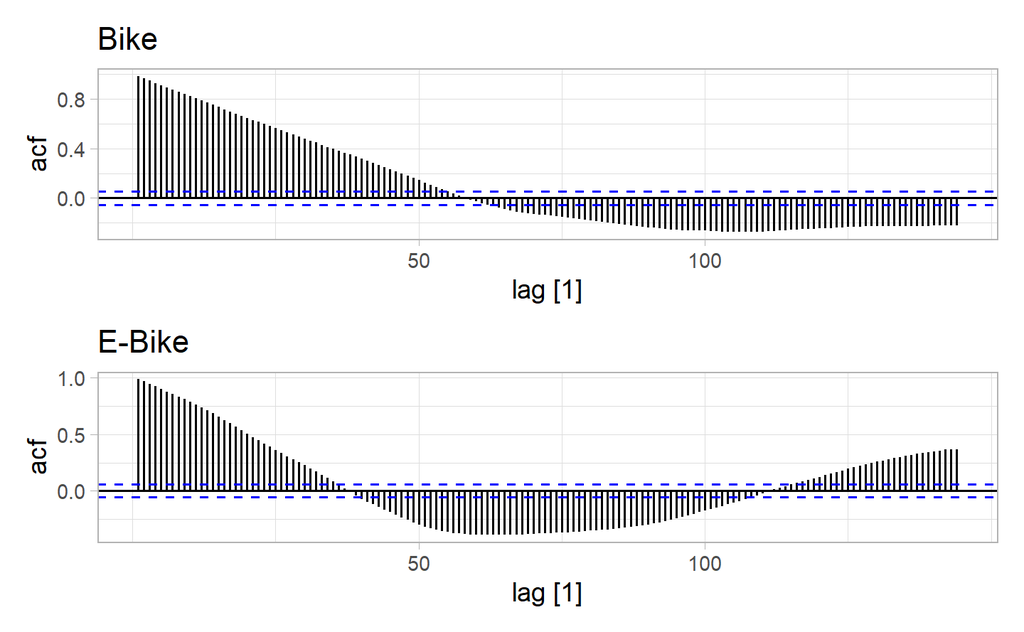

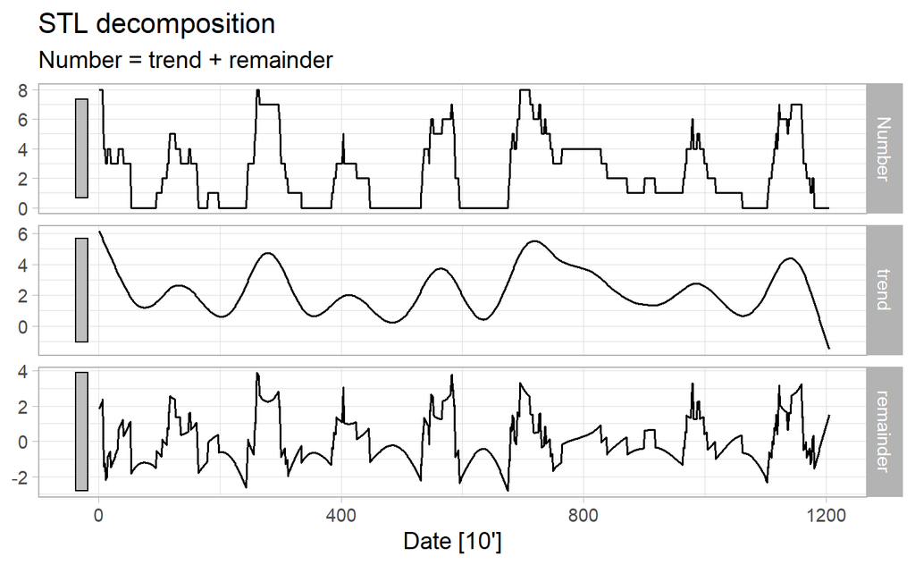

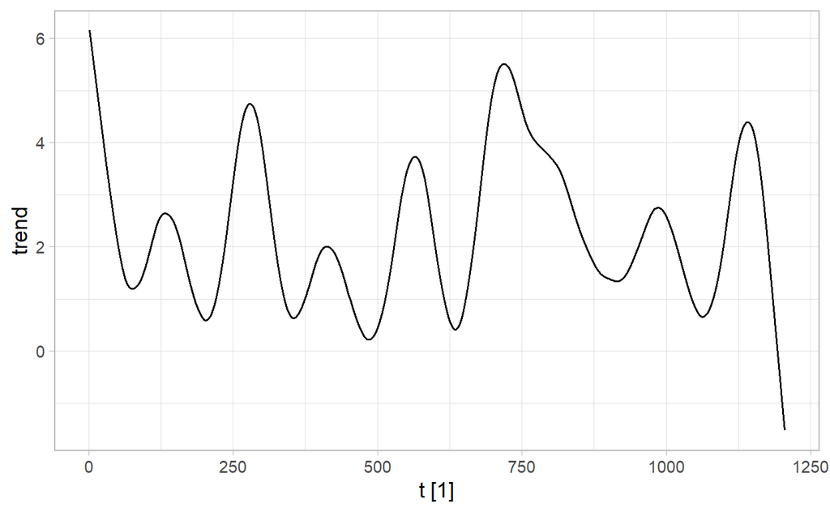

#### **Cible Station**

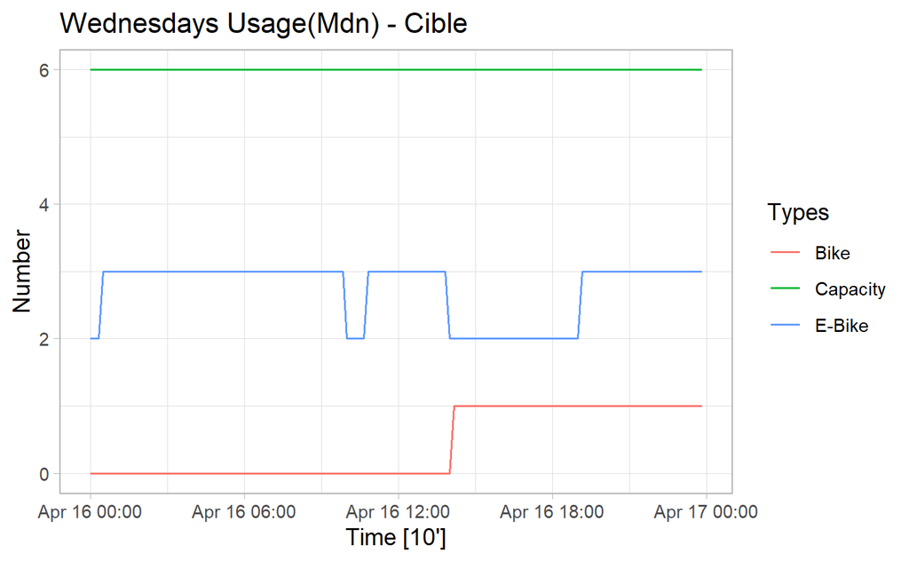

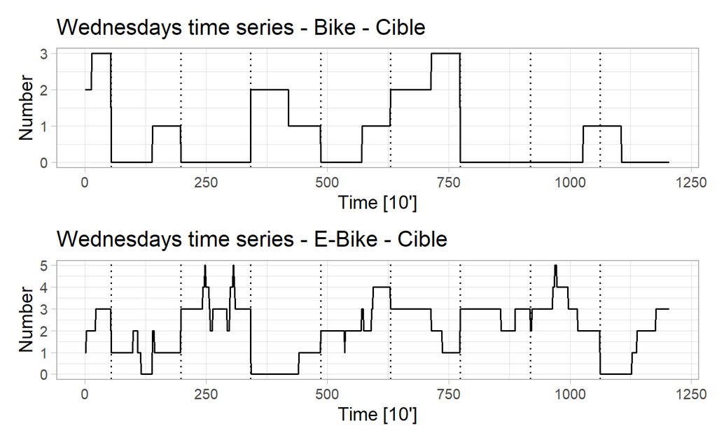

```
#> # A tibble: 1 x 3
#>   Types kpss_stat kpss_pvalue
#>   <chr>     <dbl>       <dbl>
#> 1 Bike       1.01        0.01
#> # A tibble: 1 x 3
#>   Types  kpss_stat kpss_pvalue
#>   <chr>      <dbl>       <dbl>
#> 1 E-Bike     0.890        0.01
```

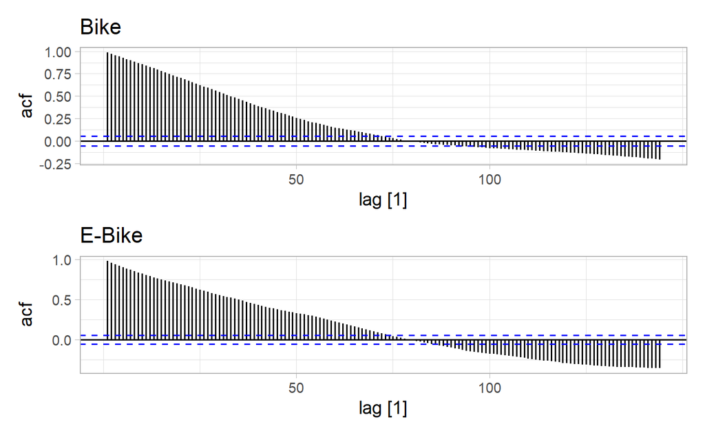

#### **Hôpital - CRR Station**

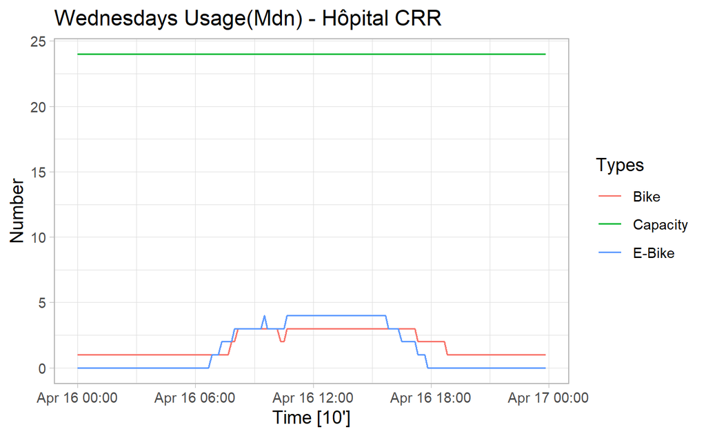

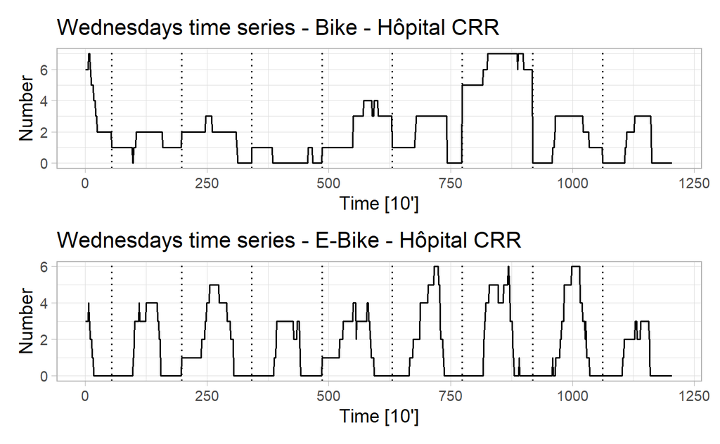

```
#> # A tibble: 1 x 3
#>   Types kpss_stat kpss_pvalue
#>   <chr>     <dbl>       <dbl>
#> 1 Bike       1.26        0.01
#> # A tibble: 1 x 3
#>   Types  kpss_stat kpss_pvalue
#>   <chr>      <dbl>       <dbl>
#> 1 E-Bike     0.102         0.1
```

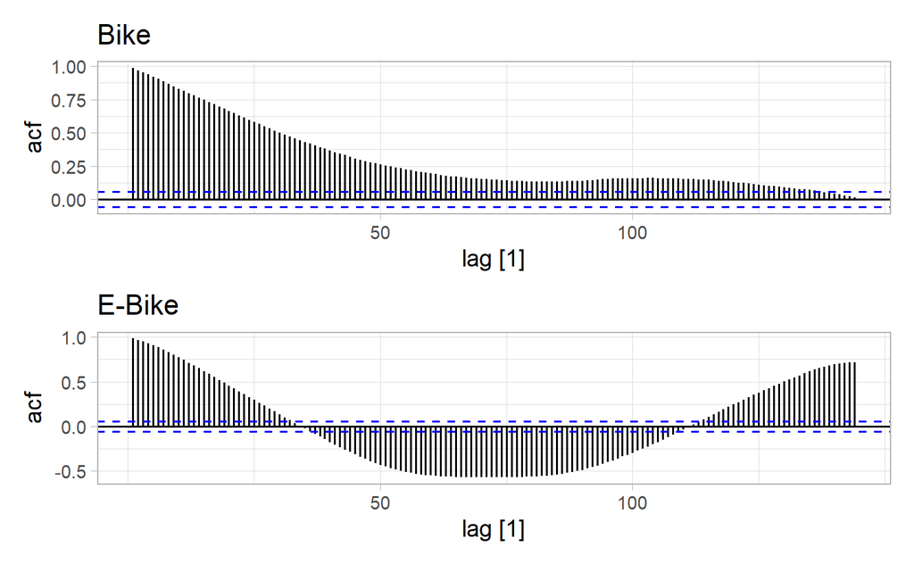

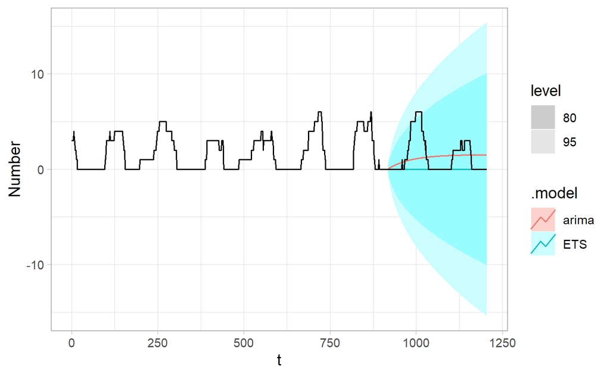

#### **Châteauneuf-Furet Station**

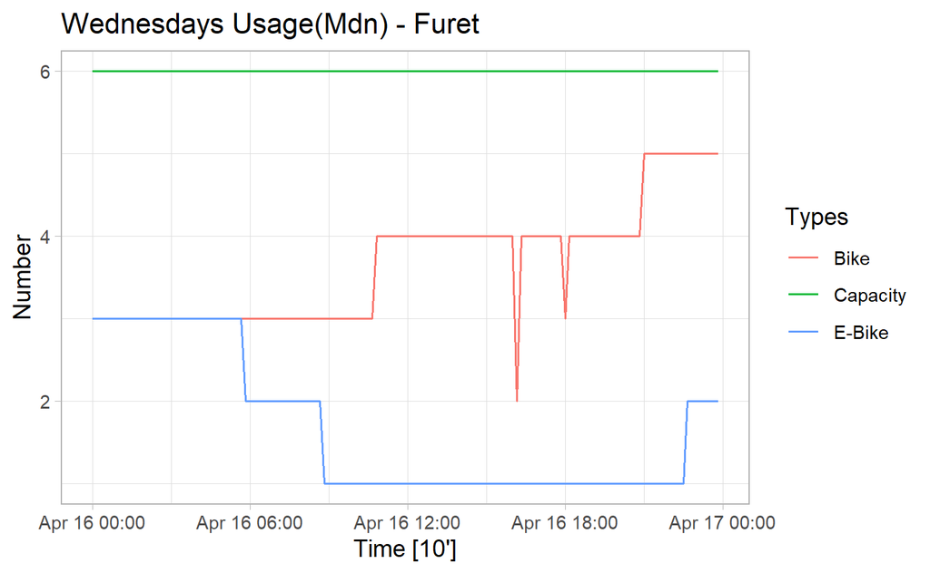

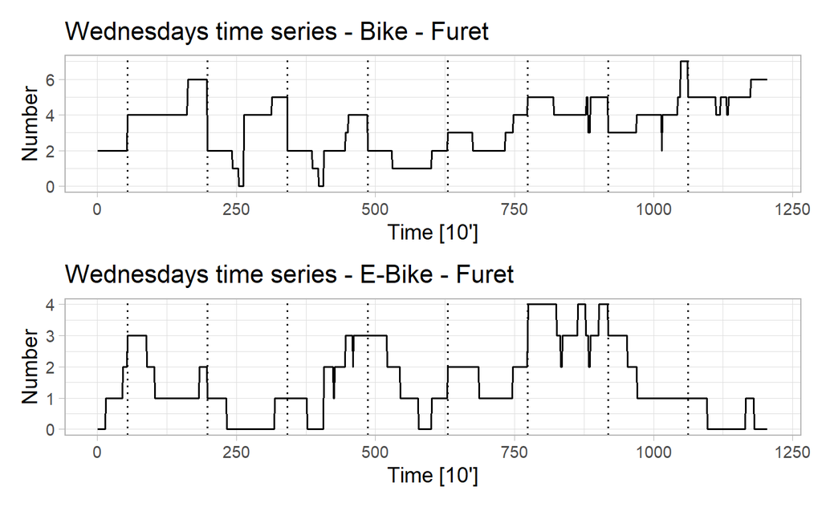

```
#> # A tibble: 1 x 3
#>   Types kpss_stat kpss_pvalue
#>   <chr>     <dbl>       <dbl>
#> 1 Bike       3.42        0.01
#> # A tibble: 1 x 3
#>   Types  kpss_stat kpss_pvalue
#>   <chr>      <dbl>       <dbl>
#> 1 E-Bike      1.24        0.01
```

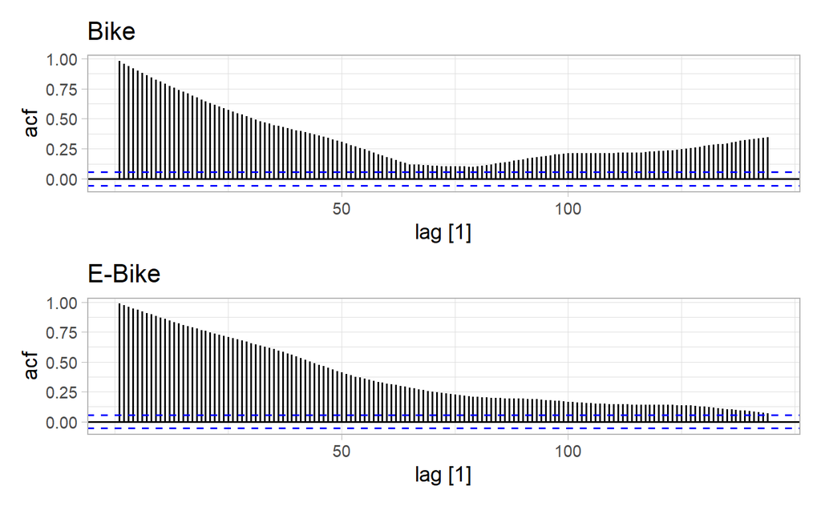